# 11.09.26.hw2.md

Martin Djamongue

2026-11-09

### Goal: Exploring the notion of chance and how it applies to significance measures, and understanding the role of the assumptions made by specific tests (e.g. the t-test) using simulations based on known distributions such as rnorm() and dbinom() and applying do real world data from DuckDB/Parquet repository.

### 1.Simulation based on rnorm, to study the performance of the “unbiased” estimator of standard deviation( n, ### n-1 & n-2 denominators)

```r
#### Setting up looping numbers ####
################################
max.sample.size <- 20
n.sim <- 10000 # number of re-samplings we are going to run for each sample size

#### Setting up matrices to save data.

sd.n <- matrix(0, nrow = n.sim , ncol =  max.sample.size) # table of data for sd with n
sd.ori <- matrix(0, nrow = n.sim, ncol = max.sample.size) # table of data for sd with n-1
sd.n2 <- matrix(0, nrow = n.sim, ncol = max.sample.size) # table of data for sd with n-2


# defining sd functions ( n, n-1, n-2)

x_sd_n <-  function( data){
  n = length( data)
  sqrt(  sum((data - mean(data))^2) / n ) # function for n
}

# sqrt(  sum((x - mean(x))^2) / (n-1)    )   # standard sd function in R for n-1

x_sd_n2 <- function( data){
  n = length( data)
  sqrt(  sum((data - mean(data))^2) / (n-2) ) # function for n-2
}

#### perform computations in a loop ####
########################################
for (sample.size in 2:max.sample.size) {
  for (i.sim in 1:n.sim) { # resample n.sim times. In each iteration:
    samp <- rnorm( sample.size , mean = 0 , sd = 1)

    # first set of sd ( n)
    sd.n [ i.sim , sample.size] <-  x_sd_n(samp)

    #second set of sd ( n-1)

    sd.ori [ i.sim , sample.size] <- sd(samp)

    # third set of sd ( n-2)

    sd.n2 [i.sim , sample.size] <- x_sd_n2(samp)

  }
}
```

### calculating the mean and spread of each of these three standard deviation estimates across all 𝑁 for current n

```r
n <- 2:max.sample.size

#apply( X = "DATAFRAME" , MARGIN = "2 -columns /. "1 - rows" , )

#mean and spread for sd.n
sd.n_mean <- apply(X = sd.n [, n], MARGIN =  2, FUN = mean)
sd.n_spread <- apply( sd.n[ , n] , 2, sd )

#mean and spread for sd.ori ( n-1)

sd.ori_mean <- apply(sd.ori[, n], 2, mean)
sd.ori_spread <- apply(sd.ori[, n], 2, sd )

#mean and spread for sd.n2 ( n-2)

sd.n2_mean <- apply(sd.n2[, n], 2, mean)
sd.n2_spread <- apply(sd.n2[, n], 2, sd )


#summary table
#
# dfr <- data.frame( n = n,
#                    sd.n_mean =sd.n_mean,
#                    sd.ori_mean = sd.ori_mean,
#                    sd.n2_mean = sd.n2_mean,
#
#                    sd.n_spread = sd.n_spread,
#                    sd.ori_spread = sd.ori_spread,
#                    sd.n2_spread = sd.n2_spread)
```

### Plot the calculated means and spreads of all three estimators of the standard deviation as functions of sample size 𝑛

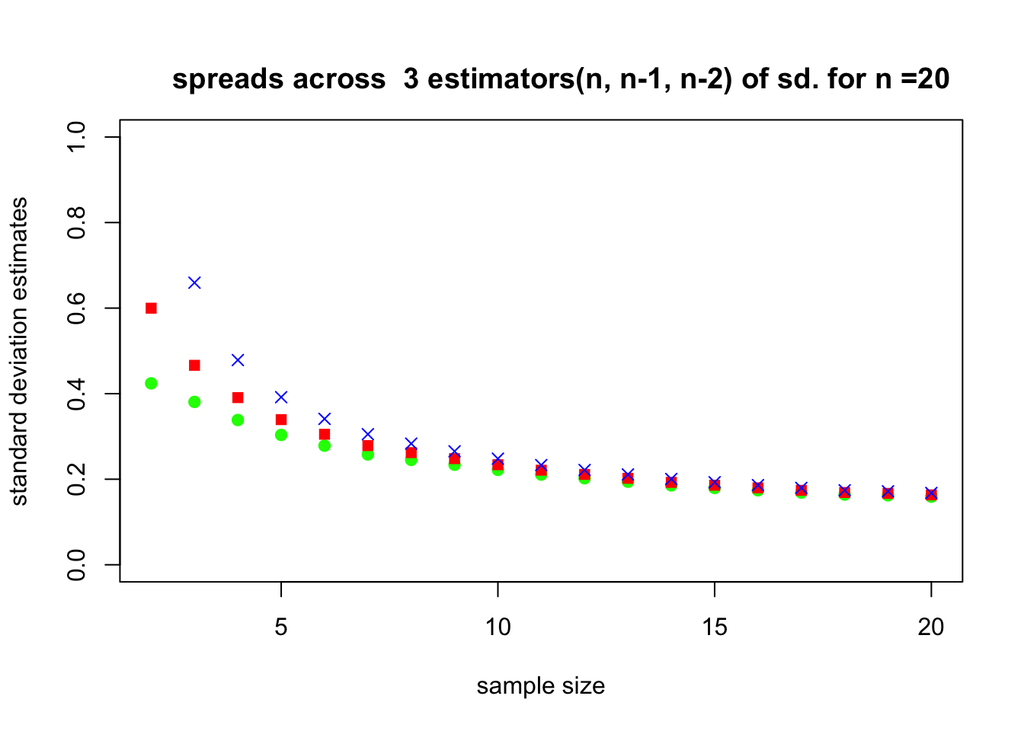

```r
# spreads across the 3 estimators of sd. against n

plot( n, sd.n2_spread, type ="n", ylim = c(0, 1) , main = "
      spreads across  3 estimators(n, n-1, n-2) of sd. for n =20 ",
      xlab = "sample size",
      ylab = "standard deviation estimates")

points( n , sd.n_spread , pch = 19 , col= "green" )
points( n , sd.ori_spread , pch = 15, col = "red")
points( n , sd.n2_spread , pch = 4 , col ="blue")
```

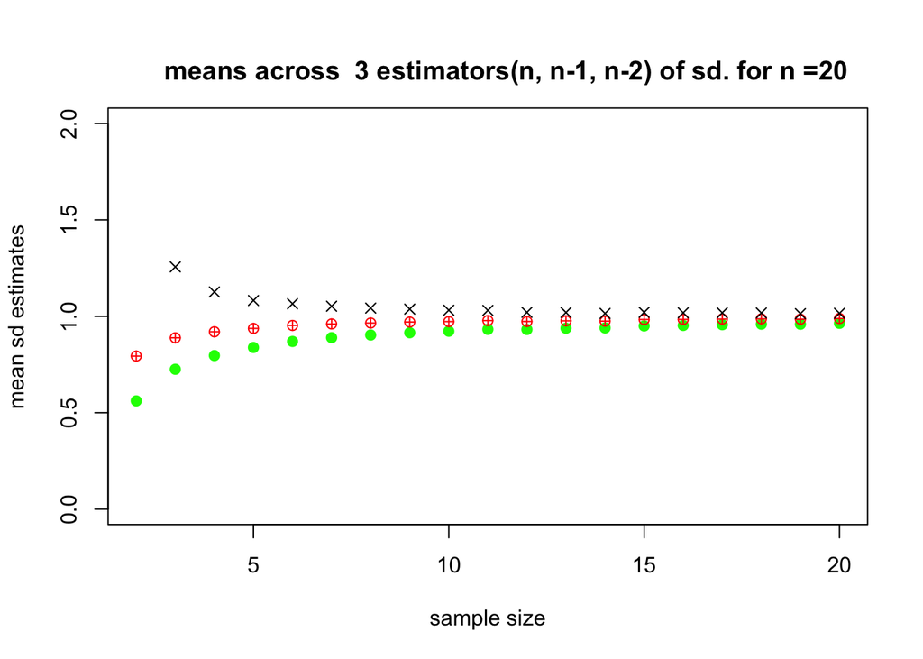

```r
#means across the 3 estimators of mean against n

plot( n, sd.n2_spread, type ="n" , ylim = c(0, 2) ,  main = "
      means across  3 estimators(n, n-1, n-2) of sd. for n =20 ",
      xlab = "sample size",
      ylab = "mean sd estimates")

points( n , sd.n_mean , pch = 19 , col= "green" ) # n
points( n , sd.ori_mean , pch = 10, col = "red") # n-1
points( n , sd.n2_mean, pch = 4 , col ="black") #n-2
```